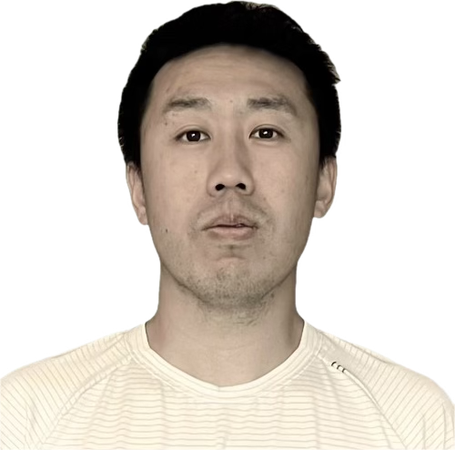

# Bio

I’m currently a Research Scientist in the [Skeletal Biology](https://yanglab.vai.org) lab led by Dr. Tao Yang at [Van Andel Institute](https://www.vai.org/).

I use R, shell scripting, and more to process omics data to understanding skeletal health and disease with primarily focused on articular knee cartilage in osteoarthritis.

My research on the epigenetic profiling of human osteoarthritis is encapsulated in the publication titled [‘Chromatin Accessibility Landscape of Articular Knee Cartilage Reveals Aberrant Enhancer Regulation in Osteoarthritis’](https://www.nature.com/articles/s41598-018-33779-z). As a follow-up study, I have published a paper titled ‘H3K9me3 loss and ERV activation as hallmarks for osteoarthritis progression and knee joint aging’ in *Osteoarthritis and Cartilage*. This study emphasizes the potential of targeting H3K9me3 levels or specific ERV families to mitigate OA progression by restoring chromatin stability and reducing inflammation, offering promising therapeutic approaches for managing OA. I also contributed the data analysis of study titled [‘TRIM28 secures skeletal stem cell fate during skeletogenesis by silencing neural gene expression and repressing GREM1/AKT/mTOR signaling axis’](https://pubmed.ncbi.nlm.nih.gov/36680774/), which investigates how loss of TRIM28 in mesoderm-derived skeletal progenitor/stem cells leads to expanded stem cell pools and ectoderm-like properties, resulting in significant defects in skeletogenesis, and study titled [‘The histone demethylase KDM5C controls female bone mass by promoting energy metabolism in osteoclasts’](https://www.science.org/doi/10.1126/sciadv.adg0731), which demonstrates that KDM5C regulates sex-specific bone mass and osteoclast metabolism, highlighting its potential as a therapeutic target for osteoporosis in women.

# Education and Research Experience

- **Apr. 2024 – Present**: Research Scientist, Laboratory of Dr. Tao Yang, [VAI](https://www.vai.org/), US
- **Apr. 2019 – Mar. 2024**: Postdoctoral Fellow, Laboratory of Dr. Tao Yang, [VAI](https://www.vai.org/), US
- **Apr. 2015 – Dec. 2018**: Junior Research Associate (JRA), Laboratory of Dr. Aki Minoda and Dr. Michael Mingta Lee, Center for Integrative Medical Sciences (IMS), [RIKEN](https://www.riken.jp/en/), Japan
- **Oct. 2018**: [Doctoral course certificate of the 6th Kyoto Course on Bioinformatics for Genomic Medicine](https://w3.genome.med.kyoto-u.ac.jp/en/course-2018-2/), [Kyoto University](https://www.kyoto-u.ac.jp/en), Japan
- **Feb. 2018 – Mar. 2018**: [Doctoral course certificate of Karolinska Institute-RIKEN joint doctoral course 2018 of Bioinformatics](https://www.ims.riken.jp/english/2018/01/003877.php), [Karolinska Institute](https://ki.se/en), Sweden
- **Feb. 2017 – Mar. 2017**: Doctoral course certificate of Bioinformatics of gene regulation in omics data and its applications to medical problems, [RIKEN](https://www.riken.jp/en/), Japan
- **Oct. 2014 – Nov. 2018**: Ph.D. of Biology Sciences, Laboratory of Dr. Zhenya Zhang, [University of Tsukuba](https://www.tsukuba.ac.jp/en/), Japan, and Laboratory of Dr. Aki Minoda, IMS, [RIKEN](https://www.riken.jp/en/), Japan
- **Jun. 2014 – Sep. 2014**: Exchange Student/Intern, Laboratory of Dr. Ran Gao, [Institute of Laboratory Animal Sciences, Chinese Academy of Medical Sciences](https://www.cnilas.org), China
- **May 2012 – Mar. 2014**: Exchange student, Laboratory of Dr. Renu Wadhawa, Biomedical Department, [National Institute of Advanced Industrial Science and Technology (AIST)](https://www.aist.go.jp/index_en.html), Japan
- **Apr. 2012 – Mar. 2014**: M.Sc. of Life and Environmental Science, Laboratory of Dr. Zhenya Zhang, [University of Tsukuba](https://www.tsukuba.ac.jp/en/), Japan, and Laboratory of Dr. Renu Wadhawa, AIST, Japan
- **Sep. 2007 – Jul. 2011**: Bachelor of Food Science and Engineering, Laboratory of Dr. Beiwei Zhu, [Dalian Polytechnic University](https://www.dlpu.edu.cn/pages/departments/), China

# Honors and Awards

- **2015 – 2018**: Research Fellowship for [Junior Research Associate (JRA)](https://www.riken.jp/en/careers/programs/jra/) program (RIKEN). The JRA program provides part-time research positions with compatible remuneration/scholarship at RIKEN for motivated graduate students enrolled in Japanese university PhD programs to develop RIKEN’s research capabilities, nurture talented young researchers, and strengthen relationships between RIKEN and Japanese universities.
- **2015**: The IMGC2015 scholarship awarded for the 29th Annual International Mammalian Genome Conference in Yokohama, Japan covered the registration fee as well as half the cost of a twin hotel room, to be shared with another attendee. The scholarship provided accommodation for five nights, from Saturday, November 7 to Thursday, November 12, 2015.
- **2018**: RIKEN-KI Joint Doctoral Course scholarship for attending the Doctoral Course at Karolinska Institute on the topic of “Bioinformatics Analysis of Gene Regulation in Omics Data and Its Applications to Medical Problems” covered cost of round-trip ticket and accommodation in Stockholm, Sweden.
- **2021**: GeoMx DSP TAP grant from NanoString Technologies, Inc. Grant Application titled “Creating an integrated spatial view of the molecular and cellular events in osteoarthritis pathogenesis” was picked as the winner of the Whole Transcriptome or high plex protein analysis of 4 human or mouse slides with Technology Access Program (TAP) in Seattle.
- **2022**: VAI Scientific Retreat Child Care Award.
- **2023**: VAI Scientific Retreat Child Care Award.

# Membership and Leadership

- **2013-2014**: Member of Japanese Tissue Culture Association, [JTCA](https://www.jtca.net)
- **2015-2016**: Member of International Mammalian Genome Society, [IMGS](https://www.imgs.org)
- **2023-2024**: Member of The American Society for Bone and Mineral Research, [ASBMR](https://www.asbmr.org/Default.aspx).
- **2023-Present**: Reviewer Board Member of MDPI, International Journal of Molecular Sciences, [IJMS](https://www.mdpi.com/journal/ijms/submission_reviewers?search=Ye+Liu)
- **2023-Present**: Topical Advisory Panel Member of MDPI, International Journal of Molecular Sciences, [IJMS](https://www.mdpi.com/journal/ijms/topical_advisory_panel?search=Ye+Liu)
- **2023-Present**: Reviewer board member of MDPI, Current Issues in Molecular Biology, [CIMB](https://www.mdpi.com/journal/cimb/submission_reviewers?search=ye+Liu)
- **2023-Present**: Topical Advisory Panel Member of MDPI, Current Issues in Molecular Biology, [CIMB](https://www.mdpi.com/journal/cimb/topical_advisory_panel?search=Ye+Liu)
- **2023**: Review Editor of Frontiers in Cellular and Infection Microbiology
- **2023-2024**: Topic Editor of Frontiers in Cellular and Infection Microbiology, Unlocking Endogenous Retroviruses in the Context of Aging-Related Diseases: Evolution, Function, and Computational Modeling Across Species
- **2023-2024**: Van Andel Institute Postdoc Leadership Committee (PLC) member, [VAI Postdoctoral Programs](https://www.vai.org/research/postdoctoral-programs/?tabUrl=current-postdocs)
- **2023-Present**: Member of Osteoarthritis Action Alliance, Van Andel Institute representative, [Osteoarthritis Action Alliance](https://oaaction.unc.edu/about-the-alliance/member-organizations/)
- **2023-Present**: Guest Editor, International Journal of Molecular Sciences, [IJMS](https://www.mdpi.com/journal/ijms/special_issues/OC7P6DTUIQ)
- **2023-Present**: Editor Board Member, Current Issues in Molecular Biology, [CIMB](https://www.mdpi.com/journal/cimb/editors?search=Ye+Liu)

# Peer-Reviewed Publications

1. **Liu Y**, Molchanov V, Zhao Y, Lu D, Liu H, Jang HJ, Yang T. H3K9me3 loss and ERV activation as hallmarks for osteoarthritis progression and knee joint aging. *Osteoarthritis and Cartilage* (2024).
2. Liu H, **Liu Y**, Jin SG, Johnson J, Xuan H, Lu D, Li J, Zhai L, Li X, Zhao Y, Liu M, Craig SEL, Floramo JS, Molchanov V, Li J, Li JD, Krawczyk C, Shi X, Pfeifer GP, Yang T. TRIM28 secures skeletal stem cell fate during skeletogenesis by silencing neural gene expression and repressing GREM1/AKT/mTOR signaling axis. *Cell Reports* 42 (1), 112012 (2023).
3. Liu H, Zhai L, **Liu Y**, Lu D, Ark AV, Yang T, Krawczyk CM. KDM5C controls female bone mass by promoting energy metabolism in osteoclasts. *Science Advances* 9, eadg0731 (2023).
4. Floramo JS, Molchanov V, Liu H, **Liu Y**, Craig SEL, Yang T. An Integrated View of Stressors as Causative Agents in OA Pathogenesis. *Biomolecules* 13 (5), 721 (2023).
5. **Liu Y**, Molchanov V, Yang T. Enzymatic Machinery of Ubiquitin and Ubiquitin-Like Modification Systems in Chondrocyte Homeostasis and Osteoarthritis. *Current Rheumatology Reports* 23 (8), 1-9 (2021).
6. Foxa GE, **Liu Y**, Turner LM, Robling AG, Yang T, Williams BO. Generation and Characterization of Mouse Models for Skeletal Disease. *Osteoporosis and Osteoarthritis*, 165-191 (2021).
7. Watanabe K, **Liu Y**, Noguchi S, Murray M, Chang JC, Kishima M, Nishimura H, Hashimoto K, Minoda A, Suzuki H. OVOL2 induces mesenchymal-to-epithelial transition in fibroblasts and enhances cell-state reprogramming towards epithelial lineages. *Scientific Reports* 9 (1), 6490 (2019).
8. Bhargava P, Malik V, **Liu Y**, Ryu J, Kaul SC, Sundar D, Wadhwa R. Molecular insights into withaferin-A-induced senescence: Bioinformatics and experimental evidence to the role of NFκB and CARF. *The Journals of Gerontology Series A: Biological Sciences and Medical Sciences* 74(2) (2018).
9. **Liu Y**, Chang JC, Hon CC, Fukui N, Tanaka N, Zhang Z, Lee MTM, Minoda A. Chromatin accessibility landscape of articular knee cartilage reveals aberrant enhancer regulation in osteoarthritis. *Scientific Reports* 8 (1), 15499 (2018).
10. Oh E, Garg S, **Liu Y**, Gao R, Yun CO, Kaul SC, Wadhwa R. Identification and Functional Characterization of Anti-metastasis and Anti-angiogenic Activities of Triethylene Glycol Derivatives. *Frontiers in oncology* 8, 552 (2018)
11. Kojo S, Tanaka H, Endo TA, Muroi S, **Liu Y**, Seo W, Tenno M, Kakugawa K, Naoe Y, Nair K, Moro K, Katsuragi Y, Kanai A, Inaba T, Egawa T, Venkatesh B, Minoda A, Kominami R, Taniuchi I. Priming of lineage-specifying genes by Bcl11b is required for lineage choice in post-selection thymocytes. *Nature communications* 8 (1), 702 (2017)
12. Nagpal N, Goyal S, Dhanjal JK, **Liu Y**, Kaul SC, Wadhwa R, Chaturvedi R, Grover A. Molecular dynamics-based identification of novel natural mortalin–p53 abrogators as anticancer agents. *Journal of Receptors and Signal Transduction* 37 (1), 8-16 (2017)
13. Li K, Yu Y, Sun S, **Liu Y**, Garg S, Kaul SC, Lei Z, Gao R, Wadhwa R, Zhang Z. Functional characterisation of anticancer activity in the aqueous extract of Helicteres angustifolia L. roots. *PloS one* 11 (3), e0152017 (2016)
14. Li Y, **Liu Y**, Wang Y, Yu Y, Zeng Y, Li L, Wang L. The Bioactivity of Fucoxanthin from Undaria pinnatifida in Vitro. *American Journal of Biochemistry and Biotechnology* 12 (2), 139-148 (2016)
15. Ryu J, Kaul Z, Yoon AR, **Liu Y**, Yaguchi T, Na Y, Ahn HM, Gao R, Choi IK, Yun CO, Kaul SC, Wadhwa R. Identification and functional characterization of nuclear mortalin in human carcinogenesis. *Journal of Biological Chemistry* 289 (36), 24832-24844 (2014)
16. Wang L, Zeng Y, **Liu Y**, Hu X,Li S, Wang Y, Li L, Lei Z, Zhang Z. Fucoxanthin induces growth arrest and apoptosis in human bladder cancer T24 cells by up-regulation of p21 and down-regulation of mortalin. *Acta Biochim Biophys Sin* 46 (10), 877-884 (2014)
17. Saxena N, Katiyar SP, **Liu Y**, Grover A, Gao R, Sundar D, Kaul SC, Wadhwa R. Molecular interactions of Bcl-2 and Bcl-xL with mortalin: identification and functional characterization. *Bioscience reports* 33 (5) (2013)

# Presentation at Domestic/International Conference

1. **Liu Y**, Liu H, Jang H S (Josh), Liu M, Zhao Y, Lu D, Yang T. The deSUMOlyase SENP6 promotes osteoclastogenesis by silencing transposable elements and suppressing IFN/STAT1 signaling. *VAI Epigenetics Symposium*. Grand Rapids, US. (2023)
2. **Liu Y**, Chang JC, Hon CC, Fukui N, Tanaka N, Zhang Z, Lee MM, Minoda A. Chromatin accessibility landscape of articular knee cartilage reveals aberrant enhancer regulation in osteoarthritis. *Human Genome Meeting 2018*. Yokohama, Japan. (2018)
3. **Liu Y**, Zhang Y, Chang JC, Lee MM, Minoda A. Genome-wide histone modification mapping for activated enhancers of articular cartilage and underlying subchondral bone in human osteoarthritic knees. *International Symposium for RIKEN Epigenetics Program 2016*. Tokyo, Japan. (2016)
4. **Liu Y**, Zhang Y, Chang JC, Minoda A, Lee MM. Genome-wide histone modification mapping for activated enhancers of articular cartilage and underlying subchondral bone in human osteoarthritic knees. *29th Annual International Mammalian Genome Conference*. Yokohama, Japan. (2015)
5. **Liu Y**, Zhang Z, Wadhwa R, Kaul SC. Ashwagandha Leaf Extract and its Active Constituents Cause Oxidative Stress to Lung Cancer Cells. *The Irago Conference 2014*. Tsukuba, Japan. (2014)
6. **Liu Y**, Zhang Z, Wadhwa R, Kaul SC. Molecular characterization of cytotoxicity of Withaferin A and Tri-ethylene glycol to human lung cancer cells. The 87th Annual Meeting (Tokyo 2014), *Japanese Tissue Culture Association*. Tokyo, Japan. (2014)
7. **Liu Y**. Anti-apoptotic proteins Bcl-2 and Bcl-xL interact with mortalin in cancer cells resulting in p53 activation. *4th ISAJ India-Japan symposium on Emerging Materials*, Tokyo, Japan. (2013)

# Peer Review Activities

- [Animals](https://www.mdpi.com/journal/animals) (2023)
- [Antioxidants](https://www.mdpi.com/journal/antioxidants) (2024)
- [Biology](https://www.mdpi.com/journal/biology) (2024)
- [Biomedicines](https://www.mdpi.com/journal/biomedicines) (2023)
- [Biomolecules](https://www.mdpi.com/journal/biomolecules) (2023)
- [BMC Musculoskeletal Disorders](https://bmcmusculoskeletdisord.biomedcentral.com) (2024)
- [Cancers](https://www.mdpi.com/journal/cancers) (2023)
- [Cells](https://www.mdpi.com/journal/cells) (2023)
- [Current Issues in Molecular Biology](https://www.mdpi.com/journal/cimb) (2023-2024)
- [Frontiers in Cellular and Infection Microbiology](https://www.frontiersin.org/journals/cellular-and-infection-microbiology) (2023)
- [Genes](https://www.mdpi.com/journal/genes) (2023)
- [Genome Biology](https://genomebiology.biomedcentral.com) (2024)
- [Healthcare](https://www.mdpi.com/journal/healthcare) (2024)
- [International Journal of Molecular Sciences](https://www.mdpi.com/journal/ijms) (2023-2024)
- [Journal of Clinical Medicine](https://www.mdpi.com/journal/jcm) (2023)
- [Medicina](https://www.mdpi.com/journal/medicina) (2024)
- [Molecules](https://www.mdpi.com/journal/molecules) (2023)
- [Nature Communications](https://www.nature.com/ncomms/) (2024)
- [Nutrients](https://www.mdpi.com/journal/nutrients) (2024)
- [Pakistan Journal of Pharmaceutical Sciences](https://www.pjps.pk/home) (2022)

# Personal Achievements

**04/23/2023**: Glass City Owens Corning Half Marathon, Toledo, Ohio  
- **Time**: 2:12:00.4  
- **Pace**: 10:05/mile  
- **Place**: 1168th of 2068

**05/13/2023**: Amway Riverbank Run 10K, Grand Rapids, Michigan  
- **Time**: 52:02.9  
- **Pace**: 8:23/mile  
- **Place**: 276th of 1796

**08/12/2023**: Mill Creek Days 5K, Comstock Park, Michigan  
- **Time**: 25:26.3  
- **Pace**: 8:11/mile  
- **Place**: 31st of 118

**07/30/2023**: Global Water Festival GR 2023, Dragon Boat Races, Grand Rapids, Michigan  
- **Result**: Team 3rd place of 12 teams

**10/15/2023**: 20th Annual 2023 Grand Rapids Marathon, Grand Rapids, Michigan  
- **Time**: 4:48:07.6  
- **Pace**: 11:00/mile  
- **Place**: 649th of 944

**05/11/2024**: Amway Riverbank Run 25K, Grand Rapids, Michigan  
- **Time**: 2:34:57.89  
- **Pace**: 9:59/mile  
- **Place**: 1777th of 2478